# Laboratório 2 - Turma 22 - 13/09/2021

## Henrique Martinez Rocamora (9836332)

## Flávio Ferreira Menten (9836691)

## Diogo Vieira (9836200)

## Pedro Henrique Campos Dini (10772797)

## Exercício 1

Um telefone celular de massa m está suspenso por quatro fios flexíveis como indicado na figura, de modo que, na configuração de equilíbrio, o plano da tela do celular está horizontal. A disposição dos fios de suspensão, assim como suas dimensões, respeita a simetria indicada (planos verticais por *C* nas direções *x* e *y*). Colocando o sistema para oscilar com pequenas amplitudes nas direções *x* e *y*, deseja-se determinar o momento de inércia do celular em torno do eixo *y* que passa pelo centro de massa C ($J_{Cyy}$). Pede-se, portanto:

[figure not shown]

### **1a)** Determinar as equações diferenciais dos movimentos horizontais do centro de massa *C* do celular nas direções *x* e *y*, supondo pequenas amplitudes de oscilação.

[figure not shown]

Rotação em torno do eixo y: $$ J_{Oyy} \ddot \Theta = -mg L \sin \Theta \\ \Theta \approx 0 \Rightarrow \sin \Theta = \Theta \Rightarrow J_{Oyy} \ddot \Theta = -mg L \Theta \\ J_{Oyy} = J_{Cyy} + mL^2 \\ ( J_{Cyy} + mL^2) \cdot \ddot \Theta = -mg L \Theta \\ $$ Translação no eixo y: $$ 2T \cos \delta = mg \\ m \ddot y = -2T \sin \delta = -mg \frac{ \sin \delta}{\cos \delta} \delta = -mg \tg \delta\\ \delta \approx 0 \Rightarrow \tg \delta = y/L \\ m \ddot y = - \frac{mg}{L} \cdot y \Rightarrow \ddot y = - \frac{g}{L} \cdot y $$

### **1b)** Determinar as frequências naturais de oscilação nas duas direções.

$$ \begin{cases} \omega_x = \sqrt{\frac{mgL}{J_{Cyy}+mL^2}} \\ \omega_y = \sqrt{\frac{g}{L} } \end{cases} $$

### **1c)** Combinando os resultados, calcular $J_{Cyy}$.

$$ (J_{Cyy} + mL^2) \cdot \omega_x^2 = mgL \Rightarrow (\frac{J_{Cyy}}{g^2} + m \cdot \frac{L^2}{g^2}) \cdot \omega_x^2 = m \cdot \frac{L}{g} \\ (\frac{J_{Cyy}}{g^2} + m \cdot \frac{1}{\omega_y^4}) \cdot \omega_x^2 = m \cdot \frac{1}{\omega_y^2} \\ \frac{J_{Cyy} \cdot \omega_x^2 }{g^2} = m \cdot \frac{1}{\omega_y^2} - m \cdot \frac{1}{\omega_y^4} \cdot \omega_x^2\\ J_{Cyy} = \frac{m g^2}{ \omega_y^4} \cdot \left( \frac{\omega_y^2}{\omega_x^2} - 1 \right) $$

## Exercício 2

Utilizando o celular que será utilizado como instrumento de medida em vários dos experimentos da disciplina, apoiá-lo sobre um cilindro de pequeno diâmetro (mina de grafite, fio de arame, carga de esferográfica) de modo a verificar a posição real do centro de massa no plano *x*, *y* e o quanto ela dista do centro do retângulo externo do celular. Com base na disposição da figura e no equacionamento correspondente, suspender o celular em dois laços de fios (linha de costura ou fio dental) de mesmo comprimento, de modo a obter um valor de *L* próximo da largura do celular. Assegurar o paralelismo dos planos da suspensão (planos verticais na direção *x*) utilizando fita adesiva para fixar os fios no celular e mantendo a mesma distância entre eles no eixo de articulação (lápis, arame, etc.). Observar que as articulações *O* e *O’* sejam o mais próximo possível de pontos materiais fixos (nós nas linhas, de modo que a distância *L* se mantenha a mesma para os movimentos em *x* e *y*). Com o sistema na configuração de equilíbrio promova ajustes de inclinação para que as leituras das acelerações em *x* e *y* sejam próximas de zero.

### **2a)** Colocando o sistema para oscilar livremente nas direções *x* e *y* registre as acelerações pelo celular e calcule, com base nas frequências de oscilação e na massa do celular (determinada com uma balança) o momento de inércia em relação ao eixo *y* pelo centro de massa *C*.

```python
import pandas as pd
import numpy as np
import matplotlib.pyplot as plt
```

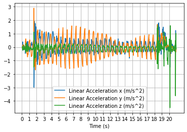

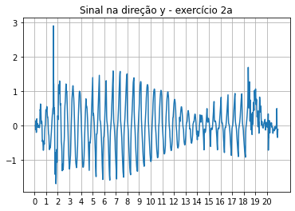

```
f_x = 1.6756 Hz
t inicio 3.469463265 t final 18.38930627
f_y = 1.7221 Hz
t inicio 3.178958265 t final 11.88921026
```

```python
df = pd.read_csv("lab2q2a1-combinado-v2.csv")

df.plot(x="Time (s)", y=["Linear Acceleration x (m/s^2)","Linear Acceleration y (m/s^2)","Linear Acceleration z (m/s^2)"], kind="line")
plt.xticks(range(0, 21, 1))
plt.grid()
plt.show()

t = df['Time (s)'].to_list()
x = df['Linear Acceleration x (m/s^2)'].to_list()
y = df['Linear Acceleration y (m/s^2)'].to_list()

plt.plot(t, y)
plt.xticks(range(0, 21, 1))
plt.title("Sinal na direção y - exercício 2a")
plt.grid()
plt.show()

t_inicial = 3
t_1 = 0
t_n = 0
N_repeticoes = 25
n_passagens = 0

for i in range(len(t)-10):
    if t[i] > t_inicial:
        if x[i]>= 0 and x[i-1]<0 :
            if n_passagens == 0 :
                t_1 = t[i]
            if n_passagens == N_repeticoes :
                t_n = t[i]
            n_passagens += 1

print(f"f_x = %.4f Hz" %(N_repeticoes/(t_n-t_1)))
print("t inicio", t_1, "t final", t_n)

t_inicial = 3
t_1 = 0
t_n = 0
N_repeticoes = 15
n_passagens = 0


for i in range(len(t)-50):
    if t[i] > t_inicial:
        if y[i]>= 0 and y[i-1]<0 :
            if n_passagens == 0 :
                t_1 = t[i]
            if n_passagens == N_repeticoes :
                t_n = t[i]
            n_passagens += 1


print(f"f_y = %.4f Hz" %(N_repeticoes/(t_n-t_1)))
print("t inicio", t_1, "t final", t_n)
```

Calculando o momento de inércia $J_{Cyy}$

Dados: Massa do celular: $m= 141g$ Distância do celular ao eixo ponto O: $L=85mm$

Dos gráficos anteriores:

$$f_x = 1.67562Hz$$$$f_y = 1.72211Hz$$

Calculando:

```python
m = 0.141
g= 9.79
omega_x = 1.67562*2*np.pi
omega_y = 1.72211*2*np.pi

print(f"omega_x = %.4f" %omega_x)
print(f"omega_y = %.4f" %omega_y)

J_Cyy = m*(g**2)*(omega_y**2/omega_x**2 - 1)/omega_y**4

print(f"J_Cyy = ", J_Cyy)
```

```
omega_x = 10.5282
omega_y = 10.8203
J_Cyy =  5.546497332900153e-05
```

### **2b)** Aplicando uma condição inicial que provoque oscilação simultânea nas duas direções, registre as acelerações nas direções *x* e *y* e verifique novamente as frequências.

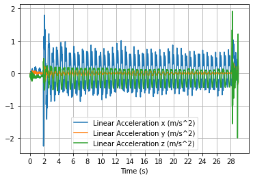

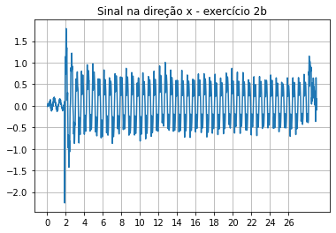

```
f_x = 1.6675 Hz
t inicio 4.242428947 t final 25.23244418
```

```python
df = pd.read_csv("lab2q2a1-x-v2.csv")

df.plot(x="Time (s)", y=["Linear Acceleration x (m/s^2)","Linear Acceleration y (m/s^2)","Linear Acceleration z (m/s^2)"], kind="line")
plt.xticks(range(0, 30, 2))
plt.grid()
plt.show()

t = df['Time (s)'].to_list()
x = df['Linear Acceleration x (m/s^2)'].to_list()
y = df['Linear Acceleration y (m/s^2)'].to_list()

plt.plot(t, x)
plt.xticks(range(0, 28, 2))
plt.title("Sinal na direção x - exercício 2b")
plt.grid()
plt.show()

t_inicial = 4
N_repeticoes = 35

n_passagens = 0

for i in range(len(t)-10):
    if t[i] > t_inicial:
        if x[i]>= 0 and x[i-1]<0 :
            if n_passagens == 0 :
                t_1 = t[i]
            if n_passagens == N_repeticoes :
                t_n = t[i]
            n_passagens += 1

print(f"f_x = %.4f Hz" %(N_repeticoes/(t_n-t_1)))
print("t inicio", t_1, "t final", t_n)
```

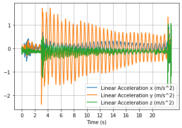

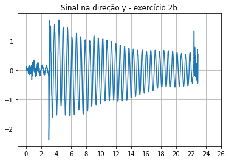

```
f_y = 1.7133 Hz
t inicio 4.233881777 t final 21.74390017
```

```python
df = pd.read_csv("lab2q2a1-y-v2.csv")

df.plot(x="Time (s)", y=["Linear Acceleration x (m/s^2)","Linear Acceleration y (m/s^2)","Linear Acceleration z (m/s^2)"], kind="line")
plt.xticks(range(0, 22, 2))
plt.grid()
plt.show()

t = df['Time (s)'].to_list()
x = df['Linear Acceleration x (m/s^2)'].to_list()
y = df['Linear Acceleration y (m/s^2)'].to_list()

plt.plot(t, y)
plt.xticks(range(0, 28, 2))
plt.title("Sinal na direção y - exercício 2b")
plt.grid()
plt.show()

t_inicial = 4
N_repeticoes = 30

n_passagens = 0

for i in range(len(t)-10):
    if t[i] > t_inicial:
        if y[i]>= 0 and y[i-1]<0 :
            if n_passagens == 0 :
                t_1 = t[i]
            if n_passagens == N_repeticoes :
                t_n = t[i]
            n_passagens += 1

print(f"f_y = %.4f Hz" %(N_repeticoes/(t_n-t_1)))
print("t inicio", t_1, "t final", t_n)
```

```python
m = 0.141
g= 9.79
omega_x = 1.6675*2*np.pi
omega_y = 1.7133*2*np.pi

print(f"omega_x = %.4f" %omega_x)
print(f"omega_y = %.4f" %omega_y)

J_Cyy = m*(g**2)*(omega_y**2/omega_x**2 - 1)/omega_y**4

print(f"J_Cyy = ", J_Cyy)
```

```
omega_x = 10.4772
omega_y = 10.7650
J_Cyy =  5.6038259218083645e-05
```

### **2c)** Com base nas incertezas observadas nos valores das frequências de oscilação, na observação do comportamento dos “pontos fixos” e no valor da massa do celular, estime a incerteza no valor de $J_{Cyy}$.

```python
from sympy import *
import numpy as np
m, g, w_y, w_x, = symbols('m g w_y w_x')


# Jc_yy = m*g**2 * (1/(w_y**2 * w_x**2)-1/w_y**4)

Jc_yy = m*g**2/w_y**4 * (w_y**2/w_x**2 - 1)

dif_m = diff(Jc_yy, m)
dif_w_y = diff(Jc_yy, w_y)
dif_w_x = diff(Jc_yy, w_x)

sigma_m = 0.001
sigma_w_y = 0.001
sigma_w_x = 0.001

sigma = dif_m**2*sigma_m**2 + dif_w_x**2*sigma_w_x**2 + dif_w_y**2*sigma_w_y**2

sigma_ = sigma.subs(m,0.141).subs(g,9.81).subs(w_x,0.5967*2*np.pi).subs(w_y,0.58068*np.pi)

pprint(sigma_)
```

```
4.96189330528303e-5
```

### **2d)** Mudando a suspensão da direção *x* para a direção *y*, repetir o experimento para determinar o $J_{Cxx}$.

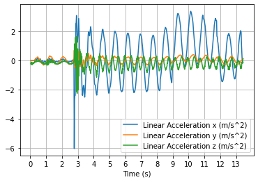

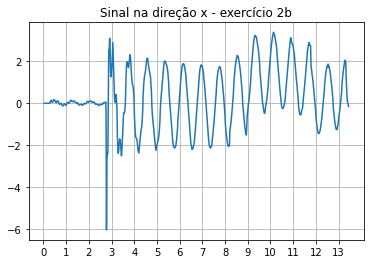

```
f_x = 1.2644 Hz
t inicio 4.388509762 t final 13.08836976
```

```python
df = pd.read_csv("lab2q2a2-x.csv")

df.plot(x="Time (s)", y=["Linear Acceleration x (m/s^2)","Linear Acceleration y (m/s^2)","Linear Acceleration z (m/s^2)"], kind="line")
plt.xticks(range(0, 14, 1))
plt.grid()
plt.show()

t = df['Time (s)'].to_list()
x = df['Linear Acceleration x (m/s^2)'].to_list()
y = df['Linear Acceleration y (m/s^2)'].to_list()

plt.plot(t, x)
plt.xticks(range(0, 14, 1))
plt.title("Sinal na direção x - exercício 2b")
plt.grid()
plt.show()

t_inicial = 4
N_repeticoes = 11

n_passagens = 0

for i in range(len(t)-10):
    if t[i] > t_inicial:
        if x[i]>= 0 and x[i-1]<0 :
            if n_passagens == 0 :
                t_1 = t[i]
            if n_passagens == N_repeticoes :
                t_n = t[i]
            n_passagens += 1

print(f"f_x = %.4f Hz" %(N_repeticoes/(t_n-t_1)))
print("t inicio", t_1, "t final", t_n)
```

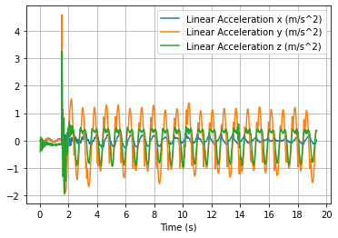

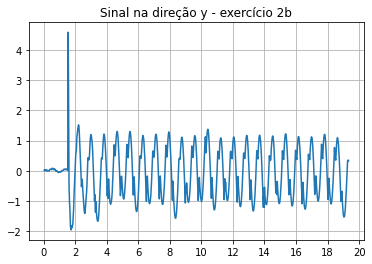

```
f_y = 1.2203 Hz
t inicio 2.00081825 t final 18.39042325
```

```python
df = pd.read_csv("lab2q2a2-y.csv")

df.plot(x="Time (s)", y=["Linear Acceleration x (m/s^2)","Linear Acceleration y (m/s^2)","Linear Acceleration z (m/s^2)"], kind="line")
plt.xticks(range(0, 22, 2))
plt.grid()
plt.show()

t = df['Time (s)'].to_list()
x = df['Linear Acceleration x (m/s^2)'].to_list()
y = df['Linear Acceleration y (m/s^2)'].to_list()

plt.plot(t, y)
plt.xticks(range(0, 22, 2))
plt.title("Sinal na direção y - exercício 2b")
plt.grid()
plt.show()

t_inicial = 2
N_repeticoes = 20

n_passagens = 0

for i in range(len(t)-10):
    if t[i] > t_inicial:
        if y[i]>= 0 and y[i-1]<0 :
            if n_passagens == 0 :
                t_1 = t[i]
            if n_passagens == N_repeticoes :
                t_n = t[i]
            n_passagens += 1

print(f"f_y = %.4f Hz" %(N_repeticoes/(t_n-t_1)))
print("t inicio", t_1, "t final", t_n)
```

```python
m = 0.141
g= 9.79
omega_x = 1.2644*2*np.pi
omega_y = 1.2203*2*np.pi

print(f"omega_x = %.4f" %omega_x)
print(f"omega_y = %.4f" %omega_y)

J_Cxx = m*(g**2)*(omega_x**2/omega_y**2 - 1)/omega_x**4

print(f"J_Cxx = ", J_Cxx)
```

```
omega_x = 7.9445
omega_y = 7.6674
J_Cxx =  0.00024963553207780424
```

### **2e)** Comparar os resultados experimentais com os teóricos calculados para uma placa retangular de mesmas dimensões externas do celular com massa uniformemente distribuída.

Cálculo para placa uniformemente distribuída

Dimensões do celular:

Altura: $h = 147,2 mm$

Largura: $ l= 69,5 mm$

Espessura $ e = 8,3 mm$

Momentos de inércia:

$$ J_{Cyy} = \frac{M}{12} \cdot (l^2 + e^2) \Rightarrow J_{Cyy} = \frac{0,141}{12} \cdot (0,0695^2 + 0,0083^2) = 5,756 \cdot 10^{-5} \;\; kg \cdot m^2 \\ J_{Cxx} = \frac{M}{12} \cdot (h^2 + e^2) \Rightarrow J_{Cyy} = \frac{0,141}{12} \cdot (0,1472^2 + 0,0083^2) = 2,554 \cdot 10^{-4} \;\; kg \cdot m^2 $$

Assim, podemos comparar os resultados obtidos: Do item 2a, com as oscilações combinadas, obtivemos o seguinte valor para o momento de inércia: $$J_{Cyy} = 5,5465 \cdot 10^{-5} \;\; kg \cdot m^2$$ E do item 2b, usando dois registros diferentes para o movimento em x e em y obtivemos: $$J_{Cyy} = 5,6038 \cdot 10^{-5} \;\; kg \cdot m^2$$

Assim observamos uma variação de 1% entre os valores obtidos pelos dois modos de cálculo. Além disso, eles se aproximam bastante do valor analítico para uma placa uniforme, sendo em média 3,1% menor. Porém, esperava-se que o valor experimental fosse menor que o valor analítico, pois o componente de maior densidade de um celular é a bateria, e ela geralmente está posicionada numa região central do dispositivo (ao menos guardando uma margem das extremidades do aparelho).

Para o momento de inércia na direção xx, o resultado obtido experimentalmente foi: $$J_{Cyy} = 2,49635 \cdot 10^{-4} \;\; kg \cdot m^2$$

Este valor é apenas 2,2% inferior ao valor obtido pelos cálculos analíticos.

Podemos concluir que, com cuidado na captura e análise dos dados, os valores obtidos experimentalmente se aproximam muito dos valores esperados.

## Exercício 3

Com o celular suspenso como indicado na figura, por quatro fios verticais de igual comprimento, de modo que as distâncias dos pontos de fixação dos fios no celular até a vertical pelo centro de massa seja aproximadamente a mesma, denominada aqui como *R*, pretende-se estudar a projeção do movimento do celular no plano horizontal que passa pelo centro de massa na posição de equilíbrio. Para tanto, sendo *x(t)* e *y(t)* os deslocamentos do centro de massa nas direções *x* e *y* indicadas na figura, e *θ(t)* o ângulo de giro do celular em torno do eixo *z*, pede-se:

[figure not shown]

### **3a)** Determinar as equações diferenciais dos movimentos oscilatórios de pequena amplitude do celular em torno da posição de equilíbrio, supondo conhecidas suas propriedades de inércia, *L* e *R*.

[figure not shown]

Rotação em torno do eixo z: $$ J_{Czz} \ddot \Theta = -4 R T \cdot \sin \delta \\ 4T \cos \delta = mg \Rightarrow 4T = \frac{mg}{\cos \delta} \\ J_{Czz} \ddot \Theta = -R \cdot mg \cdot \frac{\sin \delta }{\cos \delta }= -mR \cdot \tg \delta= mgR \cdot \frac{R \Theta}{L} \\ J_{Czz} \ddot \Theta = - \frac{mgR^2}{L} \cdot \Theta $$

[figure not shown]

Deslocamento em torno da direção y: $$ 4T \cos \delta = -mg \\ m \ddot y = 4T \sin y \\ m \ddot y = - mg \tg \delta \\ m \ddot y = - mg \frac{y}{L} \\ \ddot y = \frac{g}{L} \cdot y $$

A mesma expressão pode ser escrita para o deslocamento na direção x: $$ \ddot x = - \frac{g}{L} \cdot x $$

### **3b)** Determinar as frequências naturais de oscilação do sistema e os modos de vibrar.

$$ \omega_z = \sqrt{\frac{mR^2 \cdot g}{J_{Czz} \cdot L}} \\ \omega_x = \omega_y = \sqrt{\frac{g}{L}} $$

Os modos de vibração ligados à $\omega_x$ e a $\omega_y$ derivam da translação do aparelho no plano $xy$, com os 4 cabos paralelos. O modo de vibração $\omega_z$ está relacionado com a rotação do celular em torno do eixo $z$.

### **3c)** Supondo conhecidas as frequências naturais, o raio *R* e a massa m do celular, determinar o momento de inércia $J_{Czz}$ do celular em torno do eixo *z*.

$$ \omega_z^2 = \frac{mR^2 }{J_{Czz}} \cdot \frac{g}{L} = \frac{mR^2 }{J_{Czz}} \cdot \omega_x^2 \\ \Rightarrow J_{Czz} = mR^2 \cdot \frac{\omega_x^2}{\omega_z^2} $$

## Exercício 4

Com base na disposição da figura e no equacionamento correspondente, suspender o celular em dois laços de fios (linha de costura ou fio dental) de mesmo comprimento, e providenciar um suporte para as extremidades superiores dos fios, (tábua com pregos, estrutura de arames, etc.) de modo a assegurar o mesmo comprimento e paralelismo dos fios com o sistema na posição de equilíbrio. Se na determinação da posição do centro de massa do celular foi observado algum deslocamento significativo em relação ao centro geométrico das bordas, manter o mesmo raio *R* para os pontos de suspensão dos fios.

### **4a)** Colocando o sistema para oscilar no plano horizontal, aplicando condições iniciais adequadas, procure provocar movimento só na direção *x* e registre as acelerações pelo celular nas direções *x*, *y* e *z* do celular e determine a frequência natural de oscilação.

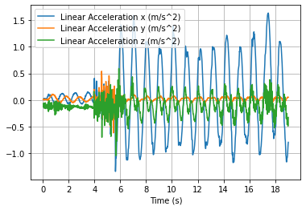

```
f_x = 0.9690 Hz
t inicio 7.821660606 t final 18.14166148
```

```python
df = pd.read_csv("lab2q4a.csv")

df.plot(x="Time (s)", y=["Linear Acceleration x (m/s^2)","Linear Acceleration y (m/s^2)","Linear Acceleration z (m/s^2)"], kind="line")
plt.xticks(range(0, 20, 2))
plt.grid()
plt.show()

t = df['Time (s)'].to_list()
x = df['Linear Acceleration x (m/s^2)'].to_list()
y = df['Linear Acceleration y (m/s^2)'].to_list()

t_inicial = 7
N_repeticoes = 10

n_passagens = 0

for i in range(len(t)-10):
    if t[i] > t_inicial:
        if x[i]>= 0 and x[i-1]<0 :
            if n_passagens == 0 :
                t_1 = t[i]
            if n_passagens == N_repeticoes :
                t_n = t[i]
            n_passagens += 1

print(f"f_x = %.4f Hz" %(N_repeticoes/(t_n-t_1)))
print("t inicio", t_1, "t final", t_n)
```

R=42mm L=258mm

### **4b)** Repita o item anterior para provocar movimento na direção *y* e determine a frequência natural de oscilação.

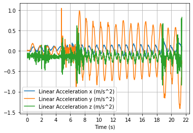

```
f_y = 0.9698 Hz
t inicio 8.971775411 t final 18.25186267
```

```python
df = pd.read_csv("lab2q4b.csv")

df.plot(x="Time (s)", y=["Linear Acceleration x (m/s^2)","Linear Acceleration y (m/s^2)","Linear Acceleration z (m/s^2)"], kind="line")
plt.xticks(range(0, 24, 2))
plt.grid()
plt.show()

t = df['Time (s)'].to_list()
x = df['Linear Acceleration x (m/s^2)'].to_list()
y = df['Linear Acceleration y (m/s^2)'].to_list()

t_inicial = 8.5
N_repeticoes = 9

n_passagens = 0

for i in range(len(t)-10):
    if t[i] > t_inicial:
        if y[i]>= 0 and y[i-1]<0 :
            if n_passagens == 0 :
                t_1 = t[i]
            if n_passagens == N_repeticoes :
                t_n = t[i]
            n_passagens += 1

print(f"f_y = %.4f Hz" %(N_repeticoes/(t_n-t_1)))
print("t inicio", t_1, "t final", t_n)
```

### **4c)** Aplicando condições iniciais que provoquem principalmente uma oscilação angular em torno de *z*, registre as acelerações nas direções *x*, *y* e *z* do celular e determine as frequências naturais de oscilação.

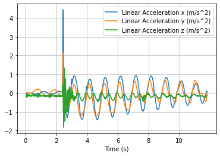

```
f_z = 1.0189 Hz
t inicio 3.936973342 t final 10.80681034
```

```python
df = pd.read_csv("lab2q4c.csv")

df.plot(x="Time (s)", y=["Linear Acceleration x (m/s^2)","Linear Acceleration y (m/s^2)","Linear Acceleration z (m/s^2)"], kind="line")
plt.xticks(range(0, 12, 2))
plt.grid()
plt.show()

t = df['Time (s)'].to_list()
x = df['Linear Acceleration x (m/s^2)'].to_list()
y = df['Linear Acceleration y (m/s^2)'].to_list()
z = df['Linear Acceleration z (m/s^2)'].to_list()

t_inicial = 3.5
N_repeticoes = 7

n_passagens = 0

for i in range(len(t)-10):
    if t[i] > t_inicial:
        if x[i]>= 0 and x[i-1]<0 :
            if n_passagens == 0 :
                t_1 = t[i]
            if n_passagens == N_repeticoes :
                t_n = t[i]
            n_passagens += 1

print(f"f_z = %.4f Hz" %(N_repeticoes/(t_n-t_1)))
print("t inicio", t_1, "t final", t_n)
```

### **4d)** Com base nas frequências de oscilação e na massa do celular, determine o momento de inércia do celular em relação ao eixo *z* pelo centro de massa *C* ($J_{Czz}$).

```python
m = 0.141
R= 0.042
omega_x =0.9698184*np.pi*2
omega_z = 1.018947*np.pi*2

J_Czz = m*(R**2)*omega_x**2/(omega_z**2)

print("J_Czz= ", J_Czz)
```

```
J_Czz=  0.00022531771722691281
```

### **4e)** Aplicando uma condição inicial que provoque oscilação simultânea nas três variáveis *x(t)*, *y(t)* e *θ(t)*, registre as acelerações nas direções *x*, *y* e *z* do celular e verifique novamente as frequências naturais. Comente os resultados.

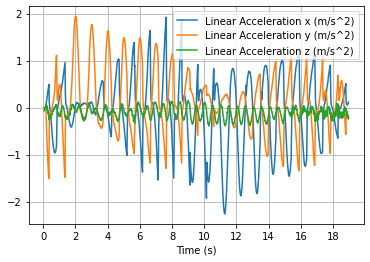

```python
df = pd.read_csv("lab2q4d.csv")

df.plot(x="Time (s)", y=["Linear Acceleration x (m/s^2)","Linear Acceleration y (m/s^2)","Linear Acceleration z (m/s^2)"], kind="line")
plt.xticks(range(0, 20, 2))
plt.grid()
plt.show()
```

Neste sinal, podemos observar muitos comportamentos simultâneos. Vemos que o movimento de rotação se apresenta, pois tem-se oscilação em z - cerca de duas a cada ciclo em x ou y. Porém as transações de x e y não podem ser desacopladas da rotação facilmente.

Fica evidente também um batimento presente. A energia é transferida entre o eixo x e o eixo y repetidamente. Na seção de codigo abaixo, a transformada rápida é utilizada, porém ainda sim não é possível caracterizar corretamente o sinal. Para isso o tempo de amostragem deveria ser mais longo.

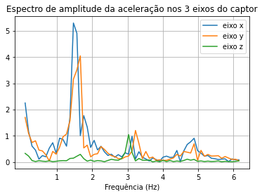

```python
from scipy import signal
from scipy.fft import fft, fftshift, fftfreq
from scipy.signal import hann, flattop, boxcar

# Sampling frequency
f_s = 100 # [Hz]
# Number of sample points
N = 1024
# sample spacing
T = 1.0 / f_s

x = df['Time (s)'].to_list()[:N]
xf = fftfreq(N, T)[:N]

y_x = df['Linear Acceleration x (m/s^2)'].to_list()[:N]
yf_x = fft(y_x)

y_y = df['Linear Acceleration y (m/s^2)'].to_list()[:N]
yf_y = fft(y_y)

y_z = df['Linear Acceleration z (m/s^2)'].to_list()[:N]
yf_z = fft(y_z)

#zoom
N=128

# graph
plt.plot(xf[1:N//2],2.0/N *np.abs(yf_x[1:N//2]))
plt.plot(xf[1:N//2],2.0/N *np.abs(yf_y[1:N//2]))
plt.plot(xf[1:N//2],2.0/N *np.abs(yf_z[1:N//2]))
plt.title('Espectro de amplitude da aceleração nos 3 eixos do captor')
plt.xlabel('Frequência (Hz)')
plt.legend(['eixo x', 'eixo y', 'eixo z'])
plt.xticks(range(1, 7, 1))
plt.grid()
plt.show()
```

### **4f)** Comparar o resultado experimental obtido para $J_{Czz}$ com o teórico calculado para uma placa retangular de mesmas dimensões externas do celular com massa uniformemente distribuída.

Cálculo para placa uniformemente distribuída

Dimensões do celular:

Altura: $h = 147,2 mm$

Largura: $ l= 69,5 mm$

Espessura $ e = 8,3 mm$

Momentos de inércia:

$$ J_{Czz} = \frac{M}{12} \cdot (l^2 + h^2) \Rightarrow J_{Cyy} = \frac{0,141}{12} \cdot (0,0695^2 + 0,1462^2) = 3,114 \cdot 10^{-4} \;\; kg \cdot m^2 \\ $$

Comparando com o valor obtido experimentalmente: $$ J_{Czz} = 2,2532 \cdot 10^{-4} \;\; kg \cdot m^2 $$

Observa-se que o momento de inércia em zz obtido experimentalmente, apesar de apresentarem a mesma ordem de grandeza, é sensivelmente inferior ao obtido pelo método analítico. Tal diferença pode-se explicar pela distribuição interna dos componentes do aparelho, que não é homogênea.